# Optimizing seqDB function

Daniel Gil

September 2018

### **Description process**

According to Wickham in his book “Advanced R”, optimizing code to make it faster is an iterative procedure:  
1. Find the biggest bottleneck (the slowest part of your code).  
2. Try to eliminate it (you may not succeed but that’s ok).  
3. Repeat until your code is “fast enough.”  
This report describes the process conducted to optimize the *seqDB* function.

### Considerations

- To be able to create multiple versions of a function without losing the location of each file, I re-organized the files that comes from the package. Now each function has its own file.
- I choose the example used in Chapter 3 of the paper “Generating Optimal Designs for Discrete Choice Experiments in R: The idefix Package” to measure the improvements in the optimization process.
- The following packages are used here:  
  **profvis**: to find bottlenecks in *seqDB* function  
  **microbenchmark**: to compare processing time of each implementation  
  **Rcpp**: to implement code in C++.  
  **RcppArmadillo**: to use built-in armadillo functions in C++.

## 1. Find the biggest bottleneck

The first step is to load all functions from the package that are used in *SeqDB* function. Because all functions were reorganized, each function need to be loaded:

```r
source("seqDB.R")
source("Derr.R")
source("InfoDes.R")
source("DBerrS.R")
source("DerrS.R")
```

Then all packages are loaded and the example is pasted as in the paper:

```r
# Load packages
library(microbenchmark)
library(profvis)
library(Rcpp)
library(RcppArmadillo)

# Run the code as in the paper.
set.seed(123)
cs <- idefix::Profiles(lvls = c(4, 3, 2), coding = c("E", "E", "E"))

# Specify prior for each respondent
m <- c(0.5, 0.5, 1, -0.3, -0.7, 0.7)
v <- diag(length(m))
ps <- MASS::mvrnorm(n = 10, mu = m, Sigma = v)

# Generate DB optimal design: 8 choice sets with 2 alternatives each
init.des <- idefix::Modfed(cand.set = cs, n.sets = 8, n.alts = 2,
                           alt.cte = c(0, 0), par.draws = ps)$design
#init.des

#   Simulate choice data for the initial design
#   True individual preference parameter
truePREF <- c(0.8, 1, 1.2, -0.4, -0.8, 1.3)

#   Simulate choices on the logit model
#   In this case, for the first five choice sets the second alternative is
#   chosen, whereas for the last three the first alternative is chosen.
set.seed(123)
y.sim <- idefix::RespondMNL(par = truePREF, des = init.des, n.alts = 2)
#y.sim

#   Updating prior distribution
set.seed(123)
draws <- idefix::ImpsampMNL(prior.mean = m, prior.covar = v,
                            des = init.des, n.alts = 2, y = y.sim, m = 6)
#draws

#   Selecting optimal choice
#   minimizing DB-error
dr <- draws$sample
w <- draws$weights
set <- SeqDB(des = init.des, cand.set = cs, n.alts = 2,
             par.draws = dr, prior.covar = v, weights = w)
set
```

```
## $set
##      Var11 Var12 Var13 Var21 Var22 Var31
## [1,]     1     0     0    -1    -1     1
## [2,]     0     0     1     1     0    -1
##
## $db.error
## [1] 0.00808191
```

```r
# Profiling seqDB function to find bottlenecks
profvis(SeqDB(des = init.des, cand.set = cs, n.alts = 2,
               par.draws = dr, prior.covar = v, weights = w))
```

[interactive chart not shown]

Multiple things can be noticed:  
- The *profvis* result shows that in the *seqDB* function the bottleneck is located in an apply function. This apply calls the *DBerrS* function.  
- In *DBerrS* function, the bottleneck is located in an apply function that calls the *DerrS* function.  
- In *DerrS* function, the bottleneck is located in the line that calls the function *InfoDes*.  
- In *InfoDes* function, there are multiple lines that takes time to process: a rep(seq()) line. The line where the probability is computed. And the line where the information matrix is computed.  
For these reasons, the biggest bottleneck is in the *InfoDes* function.

## 2. Implementation of *InfoDes* in C++ with Rcpp package.

Before implementing the code in C++, the parameters of the function *seqDB* as well as the variables created before the first apply within the function are created in the global enviroment (like an attach).

```r
# Paramaters.
des <- init.des;des # Optimal design (matrix)
```

```
##           Var11 Var12 Var13 Var21 Var22 Var31
## set1.alt1    -1    -1    -1     1     0    -1
## set1.alt2    -1    -1    -1     0     1     1
## set2.alt1     0     0     1    -1    -1    -1
## set2.alt2     0     1     0     1     0     1
## set3.alt1    -1    -1    -1     0     1    -1
## set3.alt2    -1    -1    -1     1     0     1
## set4.alt1     1     0     0     1     0     1
## set4.alt2     0     0     1     1     0     1
## set5.alt1    -1    -1    -1    -1    -1     1
## set5.alt2     0     0     1     1     0    -1
## set6.alt1     0     0     1     0     1    -1
## set6.alt2     0     1     0    -1    -1    -1
## set7.alt1     1     0     0     1     0    -1
## set7.alt2     0     1     0     0     1    -1
## set8.alt1     0     1     0     0     1    -1
## set8.alt2    -1    -1    -1     1     0    -1
```

```r
cand.set <- cs;cs # All possible treatments (matrix)
```

```
##    Var11 Var12 Var13 Var21 Var22 Var31
## 1      1     0     0     1     0     1
## 2      0     1     0     1     0     1
## 3      0     0     1     1     0     1
## 4     -1    -1    -1     1     0     1
## 5      1     0     0     0     1     1
## 6      0     1     0     0     1     1
## 7      0     0     1     0     1     1
## 8     -1    -1    -1     0     1     1
## 9      1     0     0    -1    -1     1
## 10     0     1     0    -1    -1     1
## 11     0     0     1    -1    -1     1
## 12    -1    -1    -1    -1    -1     1
## 13     1     0     0     1     0    -1
## 14     0     1     0     1     0    -1
## 15     0     0     1     1     0    -1
## 16    -1    -1    -1     1     0    -1
## 17     1     0     0     0     1    -1
## 18     0     1     0     0     1    -1
## 19     0     0     1     0     1    -1
## 20    -1    -1    -1     0     1    -1
## 21     1     0     0    -1    -1    -1
## 22     0     1     0    -1    -1    -1
## 23     0     0     1    -1    -1    -1
## 24    -1    -1    -1    -1    -1    -1
```

```r
n.alts <- 2 # Number of alternatives for each set (numeric)
par.draws <- dr # Draws from the posterior (matrix)
prior.covar <-  v;prior.covar # Prior covariance matrix (Multinormal) (matrix)
```

```
##      [,1] [,2] [,3] [,4] [,5] [,6]
## [1,]    1    0    0    0    0    0
## [2,]    0    1    0    0    0    0
## [3,]    0    0    1    0    0    0
## [4,]    0    0    0    1    0    0
## [5,]    0    0    0    0    1    0
## [6,]    0    0    0    0    0    1
```

```r
weights <- w;weights # Weights from importance sampling algorithm (numeric)
```

```
##  [1] 8.000760e-03 3.580512e-02 1.699195e-02 6.916065e-03 6.127430e-03
##  [6] 3.241708e-06 1.001706e-02 3.414615e-02 3.778920e-03 2.029903e-02
## [11] 1.118700e-02 1.332692e-02 1.563290e-02 2.336602e-02 1.989585e-02
## [16] 1.170876e-02 5.339887e-02 1.227147e-02 4.912197e-03 4.310402e-04
## [21] 1.778571e-04 2.686334e-02 1.830763e-03 3.863759e-02 2.141928e-02
## [26] 1.349242e-02 2.334183e-02 5.758426e-03 3.868060e-02 8.422354e-06
## [31] 1.608146e-02 1.250456e-02 1.150404e-02 7.545757e-03 2.591421e-02
## [36] 2.711964e-03 1.384810e-02 1.127206e-02 2.055159e-02 9.120267e-03
## [41] 3.960330e-02 4.277447e-09 4.482892e-02 1.157773e-02 1.593295e-02
## [46] 1.642301e-02 1.651583e-02 3.557230e-05 1.472142e-02 1.335188e-02
## [51] 1.950085e-02 1.854834e-02 1.184085e-02 3.529242e-02 1.074103e-02
## [56] 2.592749e-02 1.631943e-02 6.911527e-03 3.164770e-03 3.300338e-02
## [61] 5.256763e-03 7.505885e-04 1.753621e-02 1.273443e-02
```

```r
#----
# Initialize.
n.sets <- nrow(des) / n.alts # Number of sets
cte.des <- NULL #

# If no weights, equal weights.
if (is.null(weights)) {
  weights <- rep(1, nrow(par.draws)) # Each draw has weight = 1
}

# Detect alternative specific constants
des.f <- as.data.frame(des) # matrix to data.frame to use dplyr functions
alt.cte <- dplyr::select(des.f, dplyr::contains(".cte")) #  select variables
#that have that string
if (ncol(alt.cte) > 0) {
  cte.des <- alt.cte[1:n.alts, ]  # Why until n.alts?? Ans: It seems that takes the constant defined in the Modfed function. All choice sets have the same constant
}

# Handling par.draws.
if (!(is.matrix(par.draws))) {
  par.draws <- matrix(par.draws, nrow = 1) #  Transform draws that are not matrices to vector. Why? Ans: It seems that is done to give the next error
}

# Error par.draws
if (ncol(des) != ncol(par.draws)) {
  stop("Numbers of parameters in par.draws does not match the number of parameters in the design.")
}

# Error identifying model.
if (n.sets < ncol(par.draws)) { # Dont know why this error yet. Check
  stop("Model is unidentified. Increase the number of choice sets or decrease parameters to estimate.")
}

#----
# Starting and initializing values.
i.cov <- solve(prior.covar) # Inverse of prior covariance matrix
d.start <- apply(par.draws, 1, Derr, des = des,  n.alts = n.alts)

#----
# Infodes
group <- rep(seq(1, nrow(des) / n.alts, 1), each = n.alts) #Vector to

# probability of each alternative in each set
u <- des %*% diag(par.draws[1,])  #
u <- .rowSums(u, m = nrow(des), n = length(par.draws[1,]))
p <- exp(u) / rep(rowsum(exp(u), group), each = n.alts)
# information matrix
info.des <- crossprod(des * p, des) - crossprod(rowsum( des * p, group))
```

Then, the implementation is coded and sourced in R to make the comparison. To do this, each line of the *InfoDes* function was coded in C++ and tested.  
Having done this, a copy of the *seqDB* function is done, called *seqDB2*, with the following changes:  
- Calls the function *Derr2* instead of *Derr*, which calls the function *Infodes_cpp* instead of *InfoDes*.  
- Calls the function *DBerrS2* instead of *DBerrS*, which calls the function *DerrS2* which calls *Infodes_cpp* instead of *InfoDes*.  
The comparison of the results and time to execute is presented:

```r
#sourceCpp("InfoDes_cpp.cpp")
source("seqDB2.R")
set <- SeqDB(des = init.des, cand.set = cs, n.alts = 2,
             par.draws = dr, prior.covar = v, weights = w)
set2 <- SeqDB2(des = init.des, cand.set = cs, n.alts = 2,
               par.draws = dr, prior.covar = v, weights = w)
set;set2
```

```
## $set
##      Var11 Var12 Var13 Var21 Var22 Var31
## [1,]     1     0     0    -1    -1     1
## [2,]     0     0     1     1     0    -1
##
## $db.error
## [1] 0.00808191
```

```
## $set
##      Var11 Var12 Var13 Var21 Var22 Var31
## [1,]     1     0     0    -1    -1     1
## [2,]     0     0     1     1     0    -1
##
## $db.error
## [1] 0.00808191
```

```r
a <- microbenchmark(seqDB = SeqDB(des = init.des, cand.set = cs, n.alts = 2,
                     par.draws = dr, prior.covar = v, weights = w),
               seqDB2 = SeqDB2(des = init.des, cand.set = cs, n.alts = 2,
                      par.draws = dr, prior.covar = v, weights = w));a
```

```
## Unit: milliseconds
##    expr       min        lq      mean    median        uq       max neval
##   seqDB 2826.0489 2905.2374 2989.6294 2934.6235 3003.6016 3796.2612   100
##  seqDB2  493.8844  518.9172  530.3489  525.4256  536.0897  706.3257   100
##  cld
##    b
##   a
```

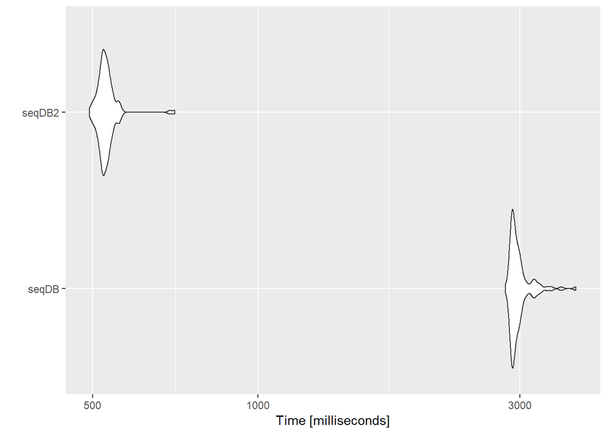

```r
autoplot.microbenchmark(a)
```

The implementation in C++ is almost **six times (6x) faster** than the original function.

## 3. Find the next biggest bottleneck

As it was mentioned before, optimization is an iterative process. So the next step is to profile this new function to find new bottlenecks.  
To do so, all elements are removed from the workspace and the example showed above is run again. Then the profiling is analized:

```r
 profvis(SeqDB2(des = init.des, cand.set = cs, n.alts = 2,
             par.draws = dr, prior.covar = v, weights = w))
```

[interactive chart not shown]

These results are similar as in the first function: - The *profvis* result shows that in the *seqDB2* function the bottleneck is located in an apply function. This apply calls the *DBerrS* function.  
- In *DBerrS2* function, the bottleneck is located in an apply function that calls the *DerrS2* function.  
- In *DerrS2* function, there are two lines, besides *InfoDes*, that takes time to process: the calculation of the determinant of the information matrix, and the append of two matrices.  
For these reasons, the next bottleneck is in the *DerrS* function.

As above, before implementing the code in C++, the parameters of the function *seqDB* as well as the variables created before the first apply within the function are created in the global enviroment (like an attach). This time there other variables that are needed.

```
##           Var11 Var12 Var13 Var21 Var22 Var31
## set1.alt1    -1    -1    -1     1     0    -1
## set1.alt2    -1    -1    -1     0     1     1
## set2.alt1     0     0     1    -1    -1    -1
## set2.alt2     0     1     0     1     0     1
## set3.alt1    -1    -1    -1     0     1    -1
## set3.alt2    -1    -1    -1     1     0     1
## set4.alt1     1     0     0     1     0     1
## set4.alt2     0     0     1     1     0     1
## set5.alt1    -1    -1    -1    -1    -1     1
## set5.alt2     0     0     1     1     0    -1
## set6.alt1     0     0     1     0     1    -1
## set6.alt2     0     1     0    -1    -1    -1
## set7.alt1     1     0     0     1     0    -1
## set7.alt2     0     1     0     0     1    -1
## set8.alt1     0     1     0     0     1    -1
## set8.alt2    -1    -1    -1     1     0    -1
```

```
##    Var11 Var12 Var13 Var21 Var22 Var31
## 1      1     0     0     1     0     1
## 2      0     1     0     1     0     1
## 3      0     0     1     1     0     1
## 4     -1    -1    -1     1     0     1
## 5      1     0     0     0     1     1
## 6      0     1     0     0     1     1
## 7      0     0     1     0     1     1
## 8     -1    -1    -1     0     1     1
## 9      1     0     0    -1    -1     1
## 10     0     1     0    -1    -1     1
## 11     0     0     1    -1    -1     1
## 12    -1    -1    -1    -1    -1     1
## 13     1     0     0     1     0    -1
## 14     0     1     0     1     0    -1
## 15     0     0     1     1     0    -1
## 16    -1    -1    -1     1     0    -1
## 17     1     0     0     0     1    -1
## 18     0     1     0     0     1    -1
## 19     0     0     1     0     1    -1
## 20    -1    -1    -1     0     1    -1
## 21     1     0     0    -1    -1    -1
## 22     0     1     0    -1    -1    -1
## 23     0     0     1    -1    -1    -1
## 24    -1    -1    -1    -1    -1    -1
```

```
##      [,1] [,2] [,3] [,4] [,5] [,6]
## [1,]    1    0    0    0    0    0
## [2,]    0    1    0    0    0    0
## [3,]    0    0    1    0    0    0
## [4,]    0    0    0    1    0    0
## [5,]    0    0    0    0    1    0
## [6,]    0    0    0    0    0    1
```

```
##  [1] 8.000760e-03 3.580512e-02 1.699195e-02 6.916065e-03 6.127430e-03
##  [6] 3.241708e-06 1.001706e-02 3.414615e-02 3.778920e-03 2.029903e-02
## [11] 1.118700e-02 1.332692e-02 1.563290e-02 2.336602e-02 1.989585e-02
## [16] 1.170876e-02 5.339887e-02 1.227147e-02 4.912197e-03 4.310402e-04
## [21] 1.778571e-04 2.686334e-02 1.830763e-03 3.863759e-02 2.141928e-02
## [26] 1.349242e-02 2.334183e-02 5.758426e-03 3.868060e-02 8.422354e-06
## [31] 1.608146e-02 1.250456e-02 1.150404e-02 7.545757e-03 2.591421e-02
## [36] 2.711964e-03 1.384810e-02 1.127206e-02 2.055159e-02 9.120267e-03
## [41] 3.960330e-02 4.277447e-09 4.482892e-02 1.157773e-02 1.593295e-02
## [46] 1.642301e-02 1.651583e-02 3.557230e-05 1.472142e-02 1.335188e-02
## [51] 1.950085e-02 1.854834e-02 1.184085e-02 3.529242e-02 1.074103e-02
## [56] 2.592749e-02 1.631943e-02 6.911527e-03 3.164770e-03 3.300338e-02
## [61] 5.256763e-03 7.505885e-04 1.753621e-02 1.273443e-02
```

```r
# Starting and initializing values.
i.cov <- solve(prior.covar) # Inverse of prior covariance matrix
d.start <- apply(par.draws, 1, Derr2, des = des,  n.alts = n.alts) #  Calculate the D-error for each alternative
db.start <- mean(d.start, na.rm = TRUE)  # Calculates the mean D-error
full.comb <- gtools::combinations(n = nrow(cand.set), r = n.alts, repeats.allowed = !reduce) # Calculates all possible combinations without repetition
n.par <- ncol(par.draws) # Number of parameters

# For each potential set, select best.
# db.errors <- apply(full.comb, 1, DBerrS2, cand.set, par.draws, des, n.alts, cte.des, i.cov, n.par, weights)

#   DBerrS2 Function
set <- as.matrix(cand.set[as.numeric(full.comb[1,]), ]) # matrix with only the alternatives chosen from the matrix of all combinations (full.comb).
# Add alternative specific constants if necessary
if (!is.null(cte.des)) {
  set <- as.matrix(cbind(cte.des, set))
}
# For each draw calculate D-error.
# d.errors <- apply(par.draws, 1, DerrS2, set, des, n.alts, i.cov, n.par)

#   DerrS2 Function
des.f <- rbind(des, set)  # Append of optimal design with new alternatives
info.d <- InfoDes(par = par.draws[1,], des = des.f, n.alts = n.alts)  # Information matrix for each row
d.error <- det(info.d + i.cov)^(-1 / n.par) # Calculate sequential d-error
```

Then, the implementation is coded and sourced in R to make the comparison. To do this, each line of the *DerrS* function was coded in C++ and tested.  
Having done this, a copy of the *seqDB* function is done, called *seqDB3*, with the following changes:  
- Calls the function *Derr2* instead of *Derr*, which calls the function *Infodes_cpp* instead of *InfoDes*.  
- Calls the function *DBerrS3* instead of *DBerrS*, which calls the function *DerrS_cpp* instead of *DerrS*.  
The comparison of the results and time to execute is presented:

```r
#sourceCpp("InfoDes_cpp.cpp")
sourceCpp("DerrS_cpp.cpp")
source("seqDB2.R")
source("seqDB3.R")

set <- SeqDB(des = init.des, cand.set = cs, n.alts = 2,
             par.draws = dr, prior.covar = v, weights = w)
set2 <- SeqDB2(des = init.des, cand.set = cs, n.alts = 2,
               par.draws = dr, prior.covar = v, weights = w)
set3 <- SeqDB3(des = init.des, cand.set = cs, n.alts = 2,
               par.draws = dr, prior.covar = v, weights = w)
set;set2;set3
```

```
## $set
##      Var11 Var12 Var13 Var21 Var22 Var31
## [1,]     1     0     0    -1    -1     1
## [2,]     0     0     1     1     0    -1
##
## $db.error
## [1] 0.00808191
```

```
## $set
##      Var11 Var12 Var13 Var21 Var22 Var31
## [1,]     1     0     0    -1    -1     1
## [2,]     0     0     1     1     0    -1
##
## $db.error
## [1] 0.00808191
```

```
## $set
##      Var11 Var12 Var13 Var21 Var22 Var31
## [1,]     1     0     0    -1    -1     1
## [2,]     0     0     1     1     0    -1
##
## $db.error
## [1] 0.00808191
```

```r
a <- microbenchmark(seqDB = SeqDB(des = init.des, cand.set = cs, n.alts = 2,
                    par.draws = dr, prior.covar = v, weights = w),
              seqDB2 = SeqDB2(des = init.des, cand.set = cs, n.alts = 2,
                     par.draws = dr, prior.covar = v, weights = w),
              seqDB3 = SeqDB3(des = init.des, cand.set = cs, n.alts = 2,
                    par.draws = dr, prior.covar = v, weights = w));a
```

```
## Unit: milliseconds
##    expr       min        lq      mean    median        uq       max neval
##   seqDB 2679.3465 2712.9558 2975.8414 2819.1179 3113.5727 4502.7714   100
##  seqDB2  478.0523  487.1125  526.6207  502.2048  541.7454  874.4709   100
##  seqDB3  597.4050  606.9934  653.2358  622.1837  685.7623  947.9537   100
##  cld
##    c
##  a
##   b
```

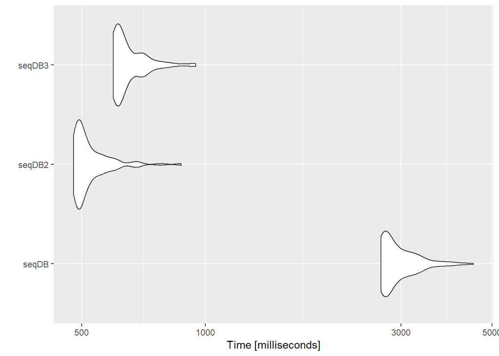

```r
autoplot.microbenchmark(a)
```

As a result, the implementation of *DerrS* does not improve the processing time with respect to *seqDB2*, which only has *InfoDes* in C++.  
The reason for this finding is that the base function *rbind* is faster that the implementation done in C++.  
However the process time of computing the determinant of the information is faster in C++:

```r
# Calculate determinant
#sourceCpp("DerrS_cpp.cpp")
det(info.d + i.cov)^(-1 / n.par) # Calculate sequential d-error
```

```
## [1] 0.4895611
```

```r
# The determinant in cpp is faster
det_cpp(info.d + i.cov)^(-1 / n.par) # Calculate sequential d-error
```

```
## [1] 0.4895611
```

```r
a = microbenchmark(R = det(info.d + i.cov)^(-1 / n.par),
               cpp = det_cpp(info.d + i.cov)^(-1 / n.par));a
```

```
## Unit: microseconds
##  expr    min      lq     mean median     uq      max neval cld
##     R 11.062 16.3960 18.68359 18.569 19.359   61.235   100   a
##   cpp  3.557  6.1245 18.69935  7.112  7.902 1168.990   100   a
```

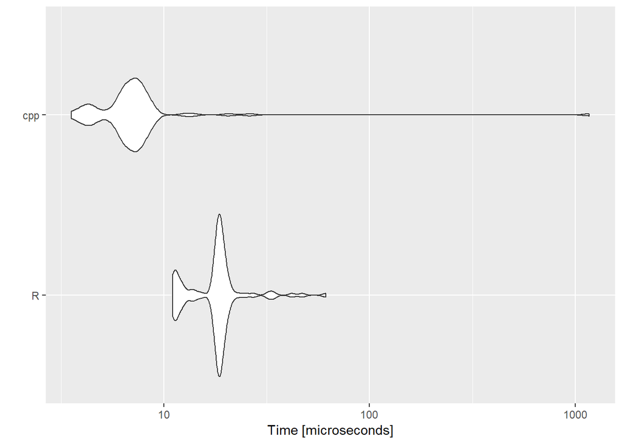

```r
autoplot.microbenchmark(a)
```

The source code of *rbind* is also done in C++, however it is much longer and complicated because it works for different kinds of R-objects. For this reason, the *rbind* function is kept in the *DerrS* function, and the determinant is computed using the C++ function.

These changes are saved in a new function called *seqDB4* and compared with the previous functions:

```r
#sourceCpp("InfoDes_cpp.cpp")
#sourceCpp("DerrS_cpp.cpp")
source("seqDB2.R")
source("seqDB3.R")
source("seqDB4.R")

set <- SeqDB(des = init.des, cand.set = cs, n.alts = 2,
             par.draws = dr, prior.covar = v, weights = w)
set2 <- SeqDB2(des = init.des, cand.set = cs, n.alts = 2,
               par.draws = dr, prior.covar = v, weights = w)
set3 <- SeqDB3(des = init.des, cand.set = cs, n.alts = 2,
               par.draws = dr, prior.covar = v, weights = w)
set4 <- SeqDB4(des = init.des, cand.set = cs, n.alts = 2,
               par.draws = dr, prior.covar = v, weights = w)
set;set2;set3;set4
```

```
## $set
##      Var11 Var12 Var13 Var21 Var22 Var31
## [1,]     1     0     0    -1    -1     1
## [2,]     0     0     1     1     0    -1
##
## $db.error
## [1] 0.00808191
```

```
## $set
##      Var11 Var12 Var13 Var21 Var22 Var31
## [1,]     1     0     0    -1    -1     1
## [2,]     0     0     1     1     0    -1
##
## $db.error
## [1] 0.00808191
```

```
## $set
##      Var11 Var12 Var13 Var21 Var22 Var31
## [1,]     1     0     0    -1    -1     1
## [2,]     0     0     1     1     0    -1
##
## $db.error
## [1] 0.00808191
```

```
## $set
##      Var11 Var12 Var13 Var21 Var22 Var31
## [1,]     1     0     0    -1    -1     1
## [2,]     0     0     1     1     0    -1
##
## $db.error
## [1] 0.00808191
```

```r
a <- microbenchmark(seqDB = SeqDB(des = init.des, cand.set = cs, n.alts = 2,
                    par.draws = dr, prior.covar = v, weights = w),
              seqDB2 = SeqDB2(des = init.des, cand.set = cs, n.alts = 2,
                     par.draws = dr, prior.covar = v, weights = w),
              seqDB3 = SeqDB3(des = init.des, cand.set = cs, n.alts = 2,
                    par.draws = dr, prior.covar = v, weights = w),
              seqDB4 = SeqDB4(des = init.des, cand.set = cs, n.alts = 2,
                    par.draws = dr, prior.covar = v, weights = w));a
```

```
## Unit: milliseconds
##    expr       min        lq      mean    median        uq       max neval
##   seqDB 2690.8325 2765.4082 2862.5716 2791.5147 2879.4248 3887.3891   100
##  seqDB2  481.4791  494.8170  505.6334  501.3460  507.4369  609.6187   100
##  seqDB3  599.0994  615.2470  643.8453  623.7809  640.6853 1132.8381   100
##  seqDB4  310.1085  319.0541  337.6519  324.2451  335.8704  548.0692   100
##   cld
##     d
##   b
##    c
##  a
```

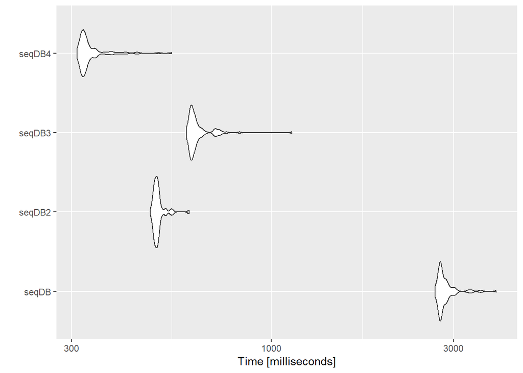

```r
autoplot.microbenchmark(a)
```

It can be seen, that this new function is again faster than the previous ones.

Now, given that a function to compute the determinant is created in C++, the function *Derr* is also modified by calling *det_cpp* function instead of *base::det*. So a new function with all these changes is created, called *seqDB5* and compared:

```r
#sourceCpp("InfoDes_cpp.cpp")
#sourceCpp("DerrS_cpp.cpp")
source("seqDB2.R")
source("seqDB3.R")
source("seqDB4.R")
source("seqDB5.R")

set <- SeqDB(des = init.des, cand.set = cs, n.alts = 2,
             par.draws = dr, prior.covar = v, weights = w)
set2 <- SeqDB2(des = init.des, cand.set = cs, n.alts = 2,
               par.draws = dr, prior.covar = v, weights = w)
set3 <- SeqDB3(des = init.des, cand.set = cs, n.alts = 2,
               par.draws = dr, prior.covar = v, weights = w)
set4 <- SeqDB4(des = init.des, cand.set = cs, n.alts = 2,
               par.draws = dr, prior.covar = v, weights = w)
set5 <- SeqDB5(des = init.des, cand.set = cs, n.alts = 2,
               par.draws = dr, prior.covar = v, weights = w)
set;set2;set3;set4;set5
```

```
## $set
##      Var11 Var12 Var13 Var21 Var22 Var31
## [1,]     1     0     0    -1    -1     1
## [2,]     0     0     1     1     0    -1
##
## $db.error
## [1] 0.00808191
```

```
## $set
##      Var11 Var12 Var13 Var21 Var22 Var31
## [1,]     1     0     0    -1    -1     1
## [2,]     0     0     1     1     0    -1
##
## $db.error
## [1] 0.00808191
```

```
## $set
##      Var11 Var12 Var13 Var21 Var22 Var31
## [1,]     1     0     0    -1    -1     1
## [2,]     0     0     1     1     0    -1
##
## $db.error
## [1] 0.00808191
```

```
## $set
##      Var11 Var12 Var13 Var21 Var22 Var31
## [1,]     1     0     0    -1    -1     1
## [2,]     0     0     1     1     0    -1
##
## $db.error
## [1] 0.00808191
```

```
## $set
##      Var11 Var12 Var13 Var21 Var22 Var31
## [1,]     1     0     0    -1    -1     1
## [2,]     0     0     1     1     0    -1
##
## $db.error
## [1] 0.00808191
```

```r
a = microbenchmark(seqDB1 = SeqDB(des = init.des, cand.set = cs, n.alts = 2,
                       par.draws = dr, prior.covar = v, weights = w),
               seqDB2 = SeqDB2(des = init.des, cand.set = cs, n.alts = 2,
                          par.draws = dr, prior.covar = v, weights = w),
               seqDB3 = SeqDB3(des = init.des, cand.set = cs, n.alts = 2,
                      par.draws = dr, prior.covar = v, weights = w),
               seqDB4 = SeqDB4(des = init.des, cand.set = cs, n.alts = 2,
                      par.draws = dr, prior.covar = v, weights = w),
               seqDB5 = SeqDB5(des = init.des, cand.set = cs, n.alts = 2,
                                par.draws = dr, prior.covar = v, weights = w));a
```

```
## Unit: milliseconds
##    expr       min        lq      mean    median        uq       max neval
##  seqDB1 2736.9813 2766.5091 2960.9785 2817.9655 3000.4591 6391.2753   100
##  seqDB2  488.0261  496.2212  515.6682  502.7753  511.6113  722.2984   100
##  seqDB3  603.9836  615.8724  641.9001  623.2885  639.3482  889.7519   100
##  seqDB4  314.6225  319.7338  337.0143  324.5998  337.2452  522.6592   100
##  seqDB5  312.7559  320.3962  338.5013  325.1294  336.8955  628.9096   100
##   cld
##     d
##   b
##    c
##  a
##  a
```

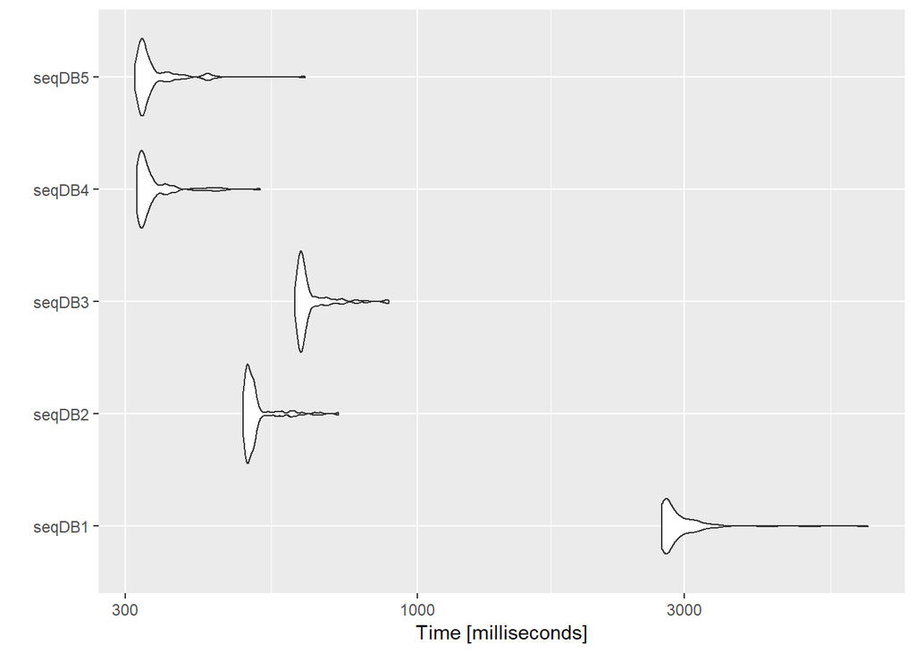

```r
autoplot.microbenchmark(a)
```

### **Conclusion**

In this sense, *seqDB* function now should call *InfoDes_cpp* and *det_cpp*.

[figure not shown]

```r
autoplot.microbenchmark(a)
```